# PENDA: PErsoNalized Data Analysis

Advanced User - Performing simulated personalized data analysis with `penda`

Magali Richard, Clémentine Decamps, Florent Chuffart, Daniel Jost

2019-04-29

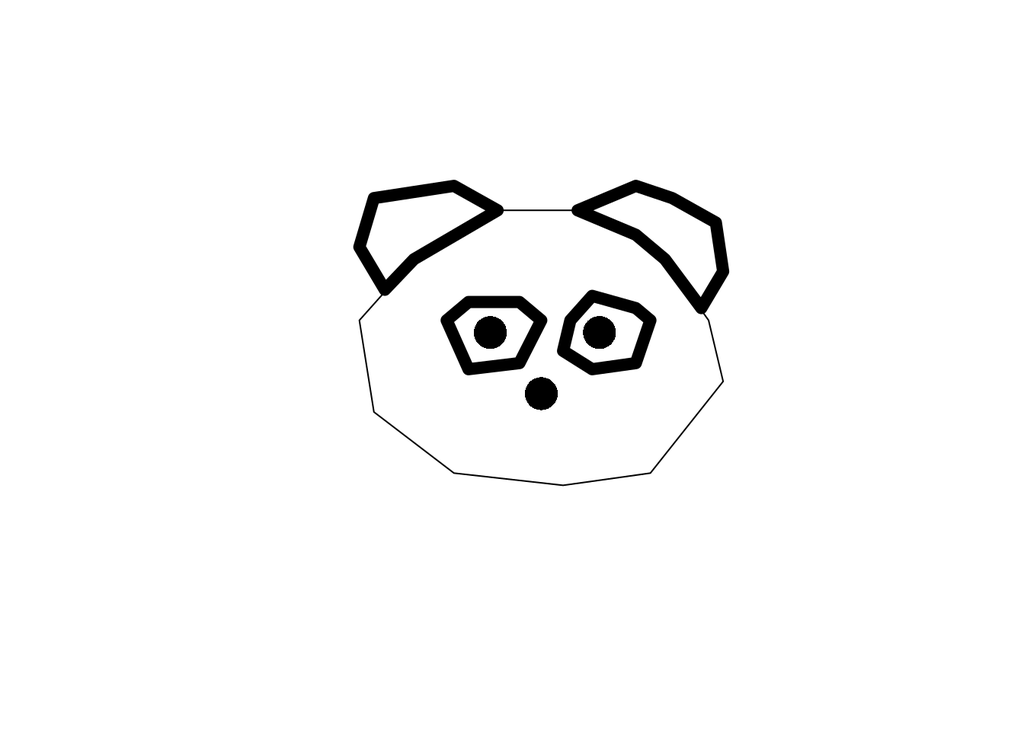

# 1 Introduction

`penda` (**PE**rso**N**alized **D**ifferential **A**nalysis ) is an open-access R package that detects gene deregulation in individual samples compared to as set of reference, control samples. To determine the variation in gene expression, PenDa uses different parameters. This tutorial aims at providing to advanced users a help to choose these different parameters according to your data.

How to cite: Richard et al. (2019) PenDa, a rank-based method for Personalized Differential Analysis: application to lung cancer, in submission.

# 2 Dataset

The dataset used to illustrated the method corresponds to the transcriptomes of 3000 genes (RNAseq counts, normalized with DESeq2) for 40 normal, control samples and 40 tumorous samples taken from the TCGA study of lung adenocarcinoma [PMID:25079552].

`data_ctrl` is a data matrix containing the normalized counts of each control sample. The rownames of the matrix correspond to the gene_symbol, the colnames indicate the sample ID.

```r
data_ctrl = penda::penda_data_ctrl
```

```
#>       patient_55-6984-11 patient_43-6773-11 patient_55-6978-11
#> AADAC           347.2489           428.5498           442.0555
#> AAMP            965.2342          1528.3221           968.0266
#> ABCA1             0.0000             0.0000             0.0000
#> ABL1           1508.1784          1227.1325          1747.2431
#> ABL2            582.6719           645.4063           488.5088
#> ACACA             0.0000             0.0000             0.0000
#> [1] 3000   40
```

`data_case` is a data matrix containing the normalized counts of each tumor sample. The rownames of the matrix correspond to the gene_symbol, the colnames indicate the sample ID.

```r
data_case = penda::penda_data_case
```

```
#>       patient_69-7764-01 patient_44-3919-01 patient_86-8278-01
#> AADAC           311.2129           374.9473          445.43169
#> AAMP           1466.5906           979.2256         1059.19225
#> ABCA1             0.0000             0.0000            0.00000
#> ABL1           2676.4306          2065.7474         2503.76905
#> ABL2           1167.0482           678.5603         1263.94317
#> ACACA             0.0000             0.0000           12.79693
#> [1] 3000   40
```

*Filtering, move to methods METHODS:*

The function `make_dataset` contains three steps to prepare the data for the analysis.

- `detect_na_value` removes rows and columns (ie, genes and samples) of the data matrices that contain more than threshold % (default value = 0.99) of NA (Not Available) value.
- `detect_zero_value` removes genes with very low expression in the majority of samples (controls and cases), ie. genes whose expression is lower than val_min in threshold % of all the samples. By default it uses the function `normalmixEM` to estimate the value of val_minusing all the log2-transformed data but this parameter can also be tuned manually by the user.
- `rank_genes` sorts genes based on the median in controls. This step is essential for the proper functioning of `penda`.

```r
data_simu = data_ctrl[,c(1:3)]
data_ctrl = data_ctrl[, -c(1:3)]
dim(data_case)
```

```
#> [1] 2441   40
```

```r
dim(data_ctrl)
```

```
#> [1] 2441   37
```

Note: this vignette is just an example. For a real analysis, we recommend to simulate more patients (10 for example).

# 3 Relative gene ordering

To use the Penda method, we need the relative gene ordering in normal tissue.

The function `compute_lower_and_higher_lists` computes two matrices of lists L and H based on the filtered control dataset (`data_ctrl`).

Each row of the **L** matrix contains a list of at most `s_max` (default value = 50) genes (characterized by their ids) whose expressions are **lower** than that of the gene correspond to the row in at least `threshold_LH` (default value = 99 %) of the control samples.  
Each row of the **H** matrix contains a list of at most `s_max` (default value = 50) genes (characterized by their ids) whose expressions are **higher** than that of the gene correspond to the row in at least `threshold_LH` (default value = 99 %) of the control samples.

Too many genes make next steps slower, but too few genes lead to errors.

```r
L[100:105,1:10]
```

```
#>        [,1] [,2] [,3] [,4] [,5] [,6] [,7] [,8] [,9] [,10]
#> MFSD11    0    0    0    0    0    0    0    0    0     0
#> STEAP2   35   34   30   27   26   25   21   20   19    17
#> REEP2    11   10    5    0    0    0    0    0    0     0
#> SERAC1   19   13   12   11   10    9    6    5    0     0
#> MST1R    47   25   21   20   19   18   16   15   13    12
#> TYK2     29   28   25   20   16   13   11   10    9     8
```

```r
H[100:105,1:10]
```

```
#>        [,1] [,2] [,3] [,4] [,5] [,6] [,7] [,8] [,9] [,10]
#> MFSD11  357  360  483  504  576  577  589  594  599   633
#> STEAP2  191  205  211  220  250  262  265  268  275   278
#> REEP2   285  316  349  353  360  365  366  370  375   380
#> SERAC1  339  383  465  604  613  632  640  645  664   666
#> MST1R   191  204  223  225  239  242  244  248  254   256
#> TYK2    177  248  255  256  267  268  270  273  282   283
```

```r
dim(L)
```

```
#> [1] 2441   50
```

```r
dim(H)
```

```
#> [1] 2441   50
```

For each gene in line (MFSD11, STEAP2, etc.), we can see the id of 10 genes with a lower expression and 10 genes with a higher expression.

# 4 Generation of the simulated dataset

To compute the real error rate, we need to use simulations. There are two methods of simulation, one simple and one more complex inspired by real dataset.

## 4.1 Simple simulation

The function `simplified_simulation` has several parameters, the first is the `fraction` of data to dysregulate. The dysregulation is +- `modifier` if the gene expression is under the `threshold`, or * / `factor` if the gene expression is above.

You have to adapt your parameters at the expected dysregulation in your real data case. The simulation returns the vector of initial data, the vector of data with modifications and the index of modified data.

## 4.2 Simulation inspired by real dataset

The function `complex_simulation` uses the real distribution of difference between data_case and data_ctrl to simulate the proportion and the value of the dysregulation.

The simulation returns the vector of initial data, the vector of data with modifications and the index of modified data.

# 5 Define optimal parameters for your dataset

We have to vary different parameters and compare the results to choose the ones that minimize the errors.

## 5.1 Parameters of the quantile method

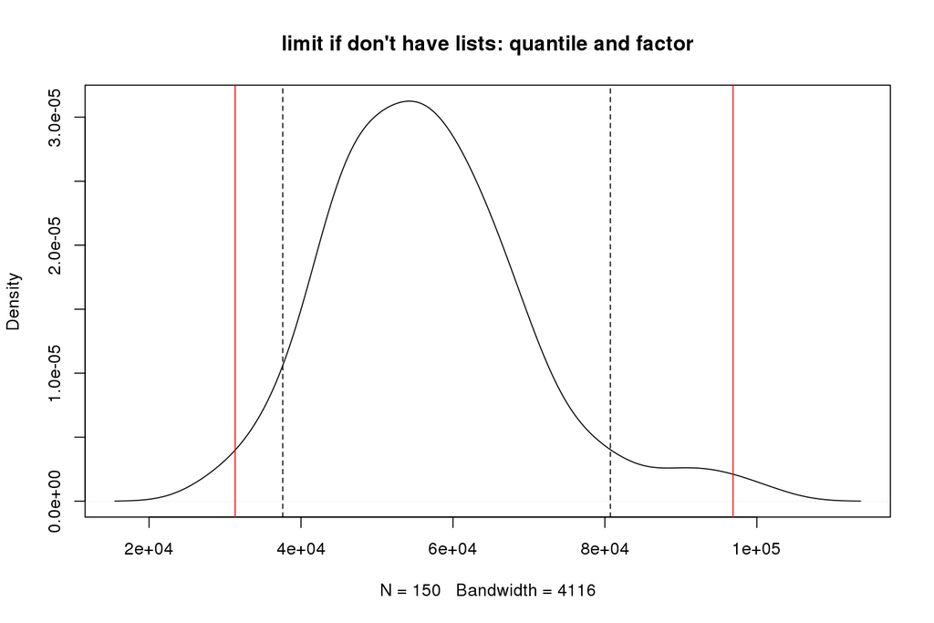

First parameters to test are those of the quantile method.  
This method is used in the Penda method when we don’t have **L** or **H** list. There are two parameters, the `quantile` of the gene expression distribution in the control (dotted line) and the `factor` which modulate this quantile value (red line).

To vary these parameters, we use the function `choose_quantile` which, for one patient, vary the quantile value for a fixed factor. This function compute then, for each quantile, three error rates.  
The **FDR**, False Discovery Rate, the proportion of false positive in all the positive results.  
The **TPR**, True Positive Rate, the proportion of true positives detected in results.  
The **FPR**, False Positive Rate, the proportion of false positive in all the negative results.

With these values, we can make a curve and choose the better quantile and the better factor, to minimize the FDR and maximize the TPR.

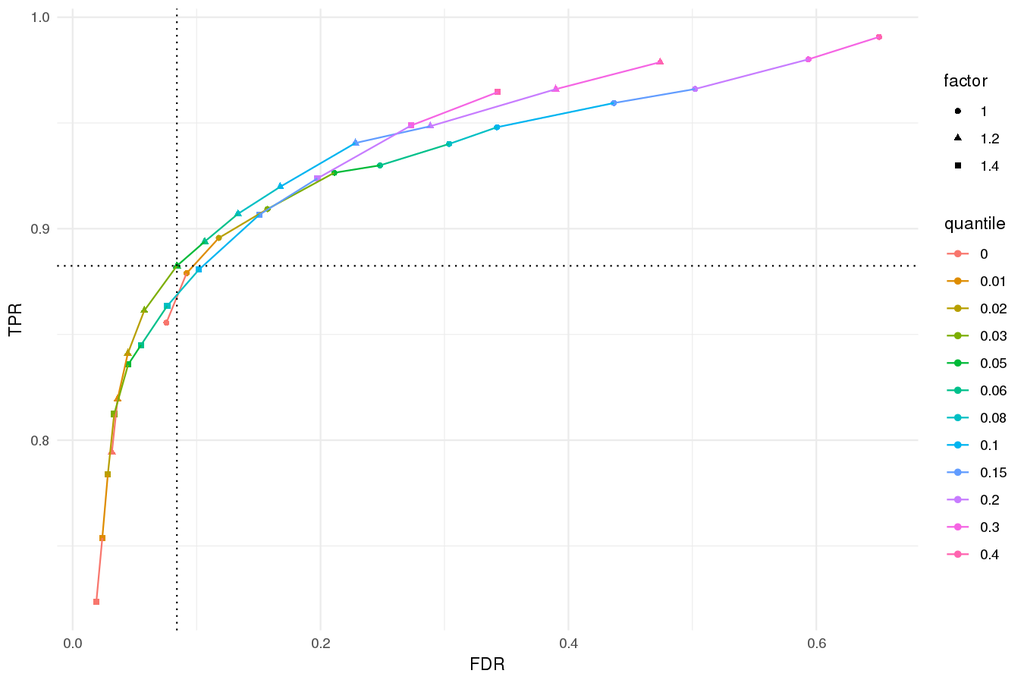

Note: this vignette is just an example. For a real analysis, we recommend to simulate different patients (10 ideally), to test more quantile and factor values and to manually choose the best settings.

## 5.2 Threshold of the Penda test

The last important parameter to choose is the `threshold` of the test. This threshold is the importance of the change of rank necessary to assert the deregulation of a gene. The function `choose_threshold` make the Penda test to different threshold values and compute the FDR, TPR and FPR.

With these values, we can make a curve and choose the better parameter to fit the experimental requirements (low FDR and high TPR).

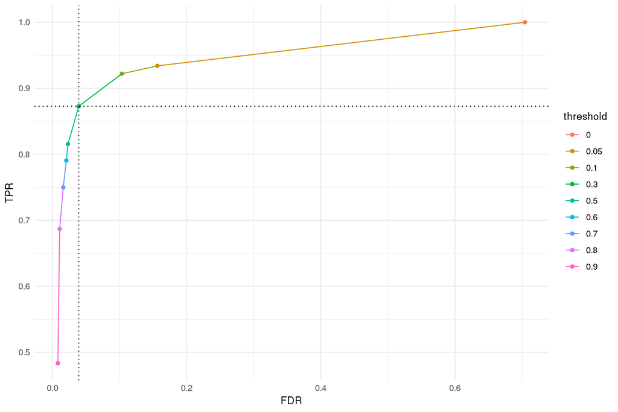

Note: this vignette is just an example. For a real analysis, we recommend to simulate different patients (10 ideally), to test more threshold values and to manually choose the best threshold.

## 5.3 Test of false positive

We applied the Penda method with computed parameters on the 3 controls used for simulation before the deregulation to see the number of false positive.

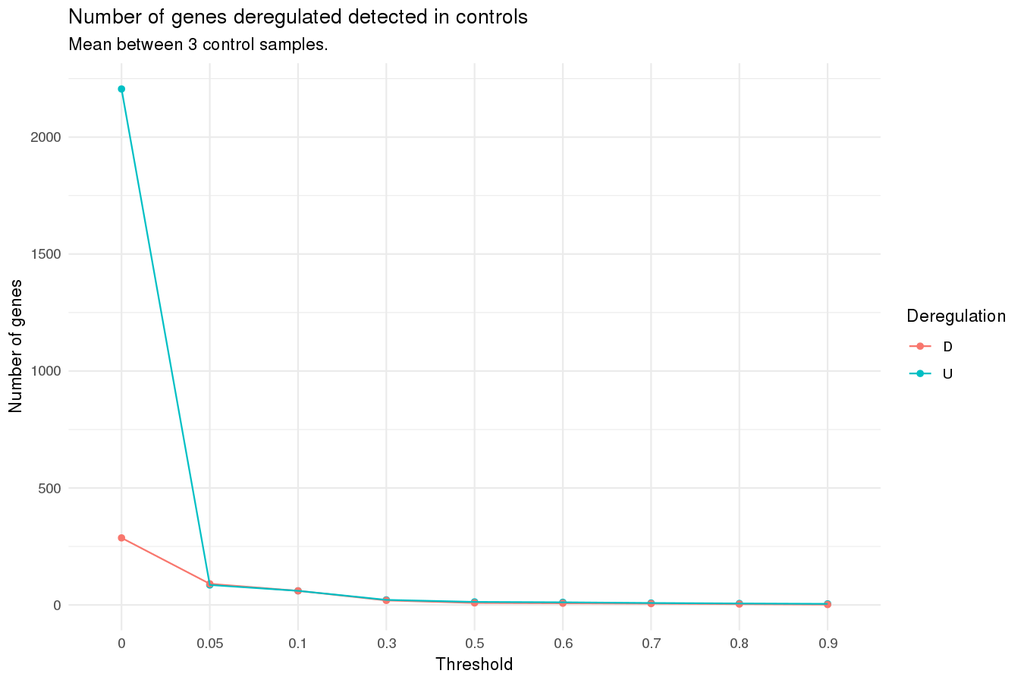

# 6 Next: analysis of your data

With these simulations you can now perform analysis on your real data. You can define your own parameters with the graph visualisation or use the automatically calculated parameters:

threshold = 0.3

quantile = 0.05

factor = 1.2

Note: being careful with recommended parameters compute on samples. For example, with the complete dataset (100 controls and 1000 datacases for 28K genes) and more simulations, we obtained different best parameters.

# 7 Material and methods

*This paragraph is automatically generated by the vignette on the parameters used. It can be used to write the “materiel and method” part of your analysis.*

The simulation vignette of the penda package version 1.0 was executed on 3000 genes, using 40 control samples and 40 case samples.

The data set was pretreated as following: 0 genes and 0 patients was removed for NA values, and 559 genes was removed for low value (under the threshold `val_min` of 483.93) in at least 99 % of cases.

3 cases samples were simulated using the complex simulation function with the following parameters: group size = 100, quantile = 0.05. Theses simulations identified 31.0118804% of genes as typically deregulated in cases samples.

37 controls were used to generate L and H lists using the following parameters: threshold LH = 0.99 and s_max = 50.

The quantile method was applied on the 3 simulated cases. We retained a global FDR value of 0.0840951, with the following set of parameters: quantile = 0.05 and factor = 1.2.

The penda method was then applied on these 3 cases. We retained a global FDR value of 0.0392632 , with the following set of parameters: quantile = 0.05, factor = 1.2 and threshold = 0.3.